# Penguins Dataset Analysis

Sourena Mohit

2025-01-26

# **Introduction**

The `palmerpenguins` dataset provides information about three species of penguins from the Palmer Archipelago.  
In this analysis, we will: - Load the dataset  
- Inspect the data structure  
- Perform basic exploratory data analysis (EDA)

## **1. Load the Dataset**

```r
# install.packages("palmerpenguins")  # Install package (only needed once)
library(palmerpenguins)  # Load the package
data("penguins")  # Load the dataset
```

## **2. Data Inspection & Summary**

```r
# View first 10 rows
head(penguins, 10)
```

| species | island | bill_length_mm | bill_depth_mm | flipper_length_mm | body_mass_g | sex | year |
| --- | --- | --- | --- | --- | --- | --- | --- |
| Adelie | Torgersen | 39.1 | 18.7 | 181 | 3750 | male | 2007 |
| Adelie | Torgersen | 39.5 | 17.4 | 186 | 3800 | female | 2007 |
| Adelie | Torgersen | 40.3 | 18.0 | 195 | 3250 | female | 2007 |
| Adelie | Torgersen | NA | NA | NA | NA | NA | 2007 |
| Adelie | Torgersen | 36.7 | 19.3 | 193 | 3450 | female | 2007 |
| Adelie | Torgersen | 39.3 | 20.6 | 190 | 3650 | male | 2007 |
| Adelie | Torgersen | 38.9 | 17.8 | 181 | 3625 | female | 2007 |
| Adelie | Torgersen | 39.2 | 19.6 | 195 | 4675 | male | 2007 |
| Adelie | Torgersen | 34.1 | 18.1 | 193 | 3475 | NA | 2007 |
| Adelie | Torgersen | 42.0 | 20.2 | 190 | 4250 | NA | 2007 |

```r
# Summary statistics
summary(penguins)
```

```
      species          island    bill_length_mm  bill_depth_mm   flipper_length_mm  body_mass_g       sex           year
 Adelie   :152   Biscoe   :168   Min.   :32.10   Min.   :13.10   Min.   :172.0     Min.   :2700   female:165   Min.   :2007
 Chinstrap: 68   Dream    :124   1st Qu.:39.23   1st Qu.:15.60   1st Qu.:190.0     1st Qu.:3550   male  :168   1st Qu.:2007
 Gentoo   :124   Torgersen: 52   Median :44.45   Median :17.30   Median :197.0     Median :4050   NA's  : 11   Median :2008
                                 Mean   :43.92   Mean   :17.15   Mean   :200.9     Mean   :4202                Mean   :2008
                                 3rd Qu.:48.50   3rd Qu.:18.70   3rd Qu.:213.0     3rd Qu.:4750                3rd Qu.:2009
                                 Max.   :59.60   Max.   :21.50   Max.   :231.0     Max.   :6300                Max.   :2009
                                 NA's   :2       NA's   :2       NA's   :2         NA's   :2
```

```r
# List all variables (column names)
names(penguins)
```

```
[1] "species"           "island"            "bill_length_mm"    "bill_depth_mm"     "flipper_length_mm" "body_mass_g"
[7] "sex"               "year"
```

```r
# Count the number of observations (rows)
nrow(penguins)
```

```
[1] 344
```

```r
# Count the number of variables (columns)
ncol(penguins)
```

```
[1] 8
```

```r
# Get dataset dimensions (rows & columns)
dim(penguins)
```

```
[1] 344   8
```

```r
# Check data types of each column
str(penguins)
```

```
tibble [344 × 8] (S3: tbl_df/tbl/data.frame)
 $ species          : Factor w/ 3 levels "Adelie","Chinstrap",..: 1 1 1 1 1 1 1 1 1 1 ...
 $ island           : Factor w/ 3 levels "Biscoe","Dream",..: 3 3 3 3 3 3 3 3 3 3 ...
 $ bill_length_mm   : num [1:344] 39.1 39.5 40.3 NA 36.7 39.3 38.9 39.2 34.1 42 ...
 $ bill_depth_mm    : num [1:344] 18.7 17.4 18 NA 19.3 20.6 17.8 19.6 18.1 20.2 ...
 $ flipper_length_mm: int [1:344] 181 186 195 NA 193 190 181 195 193 190 ...
 $ body_mass_g      : int [1:344] 3750 3800 3250 NA 3450 3650 3625 4675 3475 4250 ...
 $ sex              : Factor w/ 2 levels "female","male": 2 1 1 NA 1 2 1 2 NA NA ...
 $ year             : int [1:344] 2007 2007 2007 2007 2007 2007 2007 2007 2007 2007 ...
```

```r
# Count unique values in categorical columns
table(penguins$species)
```

```
   Adelie Chinstrap    Gentoo
      152        68       124
```

```r
table(penguins$sex)
```

```
female   male
   165    168
```

```r
table(penguins$island)
```

```
   Biscoe     Dream Torgersen
      168       124        52
```

## **3. Handling Missing Values & Data Cleaning**

```r
# Identify and count rows with missing values
sum(!complete.cases(penguins))  # Total missing rows
```

```
[1] 11
```

```r
# Check missing values per column
colSums(is.na(penguins))
```

```
          species            island    bill_length_mm     bill_depth_mm flipper_length_mm       body_mass_g               sex
                0                 0                 2                 2                 2                 2                11
             year
                0
```

```r
# Remove rows with missing values
clean_penguins <- na.omit(penguins)

# Verify changes
nrow(penguins)       # Original dataset size
```

```
[1] 344
```

```r
nrow(clean_penguins)  # Size after removing missing values
```

```
[1] 333
```

## **4. Basic Statistics & Data Manipulation**

```r
# Calculate mean and median of flipper length column (handling missing values)
mean(penguins$flipper_length_mm, na.rm = TRUE)
```

```
[1] 200.9152
```

```r
median(penguins$flipper_length_mm, na.rm = TRUE)
```

```
[1] 197
```

```r
# Filter penguins of species "Adelie" with flipper length > 200mm
filtered_penguins <- subset(penguins, species == "Adelie" & flipper_length_mm > 200)

# Create a new BMI column (Body Mass Index based on flipper length)
penguins$BMI <- penguins$body_mass_g / (penguins$flipper_length_mm ^ 2)
clean_penguins$BMI <- clean_penguins$body_mass_g / (clean_penguins$flipper_length_mm ^ 2)

# Display first 10 BMI values
head(penguins$BMI, 10)
```

```
 [1] 0.11446537 0.10983929 0.08547009         NA 0.09261994 0.10110803 0.11064986 0.12294543 0.09329110 0.11772853
```

```r
head(clean_penguins$BMI, 10)
```

```
 [1] 0.11446537 0.10983929 0.08547009 0.09261994 0.10110803 0.11064986 0.12294543 0.09660669 0.10416381 0.11223345
```

**Explanation:** - `mean()` calculates the average value of a numeric column, and `na.rm = TRUE` ensures missing values are ignored. - `median()` finds the middle value, which is useful for skewed distributions. - `subset()` is used to filter rows based on conditions (species is “Adelie” and flipper length > 200 mm). - `BMI` (Body Mass Index) is calculated as `body_mass_g / flipper_length_mm^2`, creating a new column.

## **5. Data Visualization**

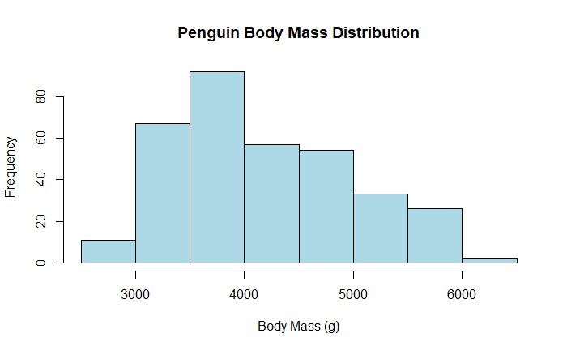

```r
# Histogram of Body Mass
hist(penguins$body_mass_g, main = "Penguin Body Mass Distribution", xlab = "Body Mass (g)", col = "lightblue")
```

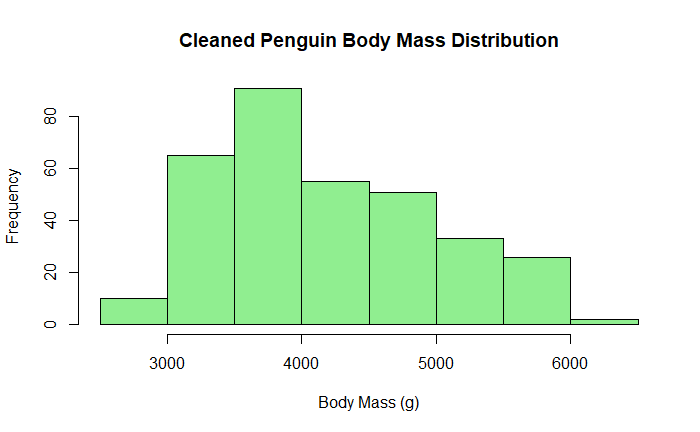

```r
hist(clean_penguins$body_mass_g, main = "Cleaned Penguin Body Mass Distribution", xlab = "Body Mass (g)", col = "lightgreen")
```

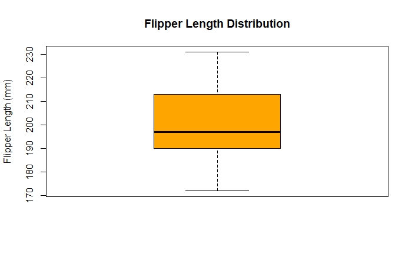

```r
# Boxplot of Flipper Length
boxplot(penguins$flipper_length_mm, main = "Flipper Length Distribution", ylab = "Flipper Length (mm)", col = "orange")
```

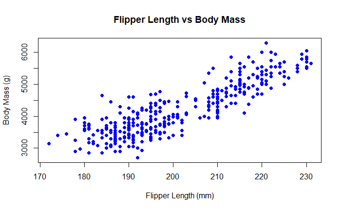

```r
# Scatter Plot: Flipper Length vs. Body Mass
plot(
  penguins$flipper_length_mm, penguins$body_mass_g,
  main = "Flipper Length vs Body Mass",
  xlab = "Flipper Length (mm)", ylab = "Body Mass (g)",
  col = "blue", pch = 16
)
```

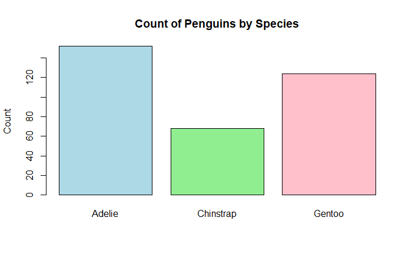

```r
# Bar Plot: Count of Penguins by Species
barplot(table(penguins$species), main = "Count of Penguins by Species", ylab = "Count", col = c("lightblue", "lightgreen", "pink"))
```

## **6. Data Grouping and Summarization**

```r
# Aggregate function: Compute mean flipper length per species
aggregate(flipper_length_mm ~ species, data = penguins, mean , na.rm = TRUE)
```

| species | flipper_length_mm |
| --- | --- |
| Adelie | 189.9536 |
| Chinstrap | 195.8235 |
| Gentoo | 217.1870 |

```r
# Count number of penguins per species-sex combination
table(penguins$species , penguins$sex)
```

```
            female male
  Adelie        73   73
  Chinstrap     34   34
  Gentoo        58   61
```

```r
# Summarize multiple variables (flipper length and body mass) per species
aggregate(cbind(flipper_length_mm, body_mass_g) ~ species, data = penguins ,
          function(x) c(mean = mean(x, na.rm = TRUE) , sd = sd(x , na.rm = TRUE)))
```

[output not shown]

**Explanation:** - `aggregate()` allows performing grouped operations. Here, we compute mean values per species. - `table()` is used to count occurrences of categorical values (species-sex combination). - `cbind()` combines multiple variables to allow summary operations on both at the same time.

## **7. Data Analysis**

```r
# Variance of flipper length
var(penguins$flipper_length_mm, na.rm = TRUE)
```

```
[1] 197.7318
```

```r
var(clean_penguins$body_mass_g)
```

```
[1] 648372.5
```

```r
# Covariance between flipper length and body mass
cov(penguins$flipper_length_mm, penguins$body_mass_g, use = "complete.obs")
```

```
[1] 9824.416
```

```r
# Correlation between flipper length and body mass
cor(penguins$flipper_length_mm, penguins$body_mass_g, use = "complete.obs")
```

```
[1] 0.8712018
```

**Explanation:** - `var()` calculates variance, which measures the spread of data. - `cov()` measures the direction of linear relationships between two variables. - `cor()` calculates correlation, which standardizes covariance and ranges from -1 to 1, showing the strength and direction of a relationship.